# **Analyzing Spotify Data**

### Fall 2025 Data Science Project

Rita Quach  
Arthur You  
Matt Hsieh  
Vishwa Dukkipati

### **Contributions**

A: Project idea  
B: Dataset Curation and Preprocessing  
C: Data Exploration and Summary Statistics  
D: ML Algorithm Design/Development  
E: ML Algorithm Training and Test Data Analysis  
F: Visualization, Result Analysis, Conclusion  
G: Final Tutorial Report Creation

**Rita: C, F, G** - Rita performed the second test, using chi square, to determine if there is a statistically significant relationship between the music platform used and a song’s popularity. She also summarized our entire process along with our findings and their implications.  
**Arthur: B, D, E, G** - Arthur imported the dataset, created the .ipynb file, and initialized the dataframe. He also performed the primary analysis creating four machine learning models with our data.  
**Matt: A, C, F, G** - Matt presented the idea of analyzing a Spotify dataset, to which the rest of the group agreed. Next, he performed the first hypothesis test: T-test, to determine if there is a statistically significant difference in mean danceability. Last, Matt created visualizations to explain the results of our analysis using four different graphs.  
**Vishwa: C, D, G** - Vishwa performed the third and final test, using Pearson’s correlation test, to investigate if there is a linear correlation between the various metrics for each song. And, he wrote guiding messages throughout the section to explain the process to readers.

### **Introduction**

Our topic is analyzing a Spotify dataset. We chose this dataset because it is highly relevant to our age bracket as college students, as most of us are avid music listeners that use Spotify to stream music. The data itself is especially interesting due to its sheer volume: there are over 900 unique songs with 24 different metrics for each song, giving more than enough data to draw interesting conclusions and discover what is popular on Spotify. For instance, we can determine which artist is releasing the most songs that end up in the highest number of playlists, or which songs are getting the most streams and why they might be more popular than others. Some questions we are posing:

- What makes a song popular?
- What is the definition of popular?
- Can we identify characteristics of a song that will make it popular?

From a college student perspective, answering these questions will do little to benefit our lives. However, it'll be fun to know why some songs are more popular than others- when a tune comes up, we can listen for those features.

### **Data Curation**

```python
# Preprocessing
import pandas as pd
import matplotlib.pyplot as plt
from scipy import stats
import seaborn as sns
from scipy.stats import chi2_contingency
import numpy as np
```

```python
#Ignore future warnings
import warnings
warnings.filterwarnings("ignore", category=FutureWarning)
```

```python
#Read the csv with our data into a dataframe
df = pd.read_csv("SpotifyData.csv", encoding="latin1")

display(df.head())
```

|  | track_name | artist(s)_name | artist_count | released_year | released_month | released_day | in_spotify_playlists | in_spotify_charts | streams | in_apple_playlists | ... | bpm | key | mode | danceability_% | valence_% | energy_% | acousticness_% | instrumentalness_% | liveness_% | speechiness_% |
| --- | --- | --- | --- | --- | --- | --- | --- | --- | --- | --- | --- | --- | --- | --- | --- | --- | --- | --- | --- | --- | --- |
| 0 | Seven (feat. Latto) (Explicit Ver.) | Latto, Jung Kook | 2 | 2023 | 7 | 14 | 553 | 147 | 141381703 | 43 | ... | 125 | B | Major | 80 | 89 | 83 | 31 | 0 | 8 | 4 |
| 1 | LALA | Myke Towers | 1 | 2023 | 3 | 23 | 1474 | 48 | 133716286 | 48 | ... | 92 | C# | Major | 71 | 61 | 74 | 7 | 0 | 10 | 4 |
| 2 | vampire | Olivia Rodrigo | 1 | 2023 | 6 | 30 | 1397 | 113 | 140003974 | 94 | ... | 138 | F | Major | 51 | 32 | 53 | 17 | 0 | 31 | 6 |
| 3 | Cruel Summer | Taylor Swift | 1 | 2019 | 8 | 23 | 7858 | 100 | 800840817 | 116 | ... | 170 | A | Major | 55 | 58 | 72 | 11 | 0 | 11 | 15 |
| 4 | WHERE SHE GOES | Bad Bunny | 1 | 2023 | 5 | 18 | 3133 | 50 | 303236322 | 84 | ... | 144 | A | Minor | 65 | 23 | 80 | 14 | 63 | 11 | 6 |

5 rows × 24 columns

```python
#Info on each column in the dataframe
summary = pd.DataFrame({
    "Non-Null Count": df.notna().sum(),
    "Dtype": df.dtypes,
})
summary
```

|  | Non-Null Count | Dtype |
| --- | --- | --- |
| track_name | 953 | object |
| artist(s)_name | 953 | object |
| artist_count | 953 | int64 |
| released_year | 953 | int64 |
| released_month | 953 | int64 |
| released_day | 953 | int64 |
| in_spotify_playlists | 953 | int64 |
| in_spotify_charts | 953 | int64 |
| streams | 953 | object |
| in_apple_playlists | 953 | int64 |
| in_apple_charts | 953 | int64 |
| in_deezer_playlists | 953 | object |
| in_deezer_charts | 953 | int64 |
| in_shazam_charts | 903 | object |
| bpm | 953 | int64 |
| key | 858 | object |
| mode | 953 | object |
| danceability_% | 953 | int64 |
| valence_% | 953 | int64 |
| energy_% | 953 | int64 |
| acousticness_% | 953 | int64 |
| instrumentalness_% | 953 | int64 |
| liveness_% | 953 | int64 |
| speechiness_% | 953 | int64 |

```python
# Convert Objects to Numeric
df['streams'] = pd.to_numeric(df['streams'], errors='coerce')
df['in_deezer_playlists'] = pd.to_numeric(df['in_deezer_playlists'], errors='coerce')
df['in_shazam_charts'] = pd.to_numeric(df['in_shazam_charts'], errors='coerce')
```

```python
#How many null values in each column
df.isnull().sum().to_frame(name="Missing Values")
```

|  | Missing Values |
| --- | --- |
| track_name | 0 |
| artist(s)_name | 0 |
| artist_count | 0 |
| released_year | 0 |
| released_month | 0 |
| released_day | 0 |
| in_spotify_playlists | 0 |
| in_spotify_charts | 0 |
| streams | 1 |
| in_apple_playlists | 0 |
| in_apple_charts | 0 |
| in_deezer_playlists | 79 |
| in_deezer_charts | 0 |
| in_shazam_charts | 57 |
| bpm | 0 |
| key | 95 |
| mode | 0 |
| danceability_% | 0 |
| valence_% | 0 |
| energy_% | 0 |
| acousticness_% | 0 |
| instrumentalness_% | 0 |
| liveness_% | 0 |
| speechiness_% | 0 |

```python
# Imputing missing values
df['key'] = df['key'].fillna('C')
numeric_cols_to_fill = ['streams', 'in_deezer_playlists', 'in_shazam_charts']

for col in numeric_cols_to_fill:
    median_val = df[col].median()

    df[col] = df[col].fillna(median_val)
```

```python
# Final check, dataframe info + null count
final_summary = pd.DataFrame({
        "Non-Null Count": df.notna().sum(),
        "Null Count": df.isnull().sum(),
        "Dtype": df.dtypes.astype(str)
    })
final_summary
```

|  | Non-Null Count | Null Count | Dtype |
| --- | --- | --- | --- |
| track_name | 953 | 0 | object |
| artist(s)_name | 953 | 0 | object |
| artist_count | 953 | 0 | int64 |
| released_year | 953 | 0 | int64 |
| released_month | 953 | 0 | int64 |
| released_day | 953 | 0 | int64 |
| in_spotify_playlists | 953 | 0 | int64 |
| in_spotify_charts | 953 | 0 | int64 |
| streams | 953 | 0 | float64 |
| in_apple_playlists | 953 | 0 | int64 |
| in_apple_charts | 953 | 0 | int64 |
| in_deezer_playlists | 953 | 0 | float64 |
| in_deezer_charts | 953 | 0 | int64 |
| in_shazam_charts | 953 | 0 | float64 |
| bpm | 953 | 0 | int64 |
| key | 953 | 0 | object |
| mode | 953 | 0 | object |
| danceability_% | 953 | 0 | int64 |
| valence_% | 953 | 0 | int64 |
| energy_% | 953 | 0 | int64 |
| acousticness_% | 953 | 0 | int64 |
| instrumentalness_% | 953 | 0 | int64 |
| liveness_% | 953 | 0 | int64 |
| speechiness_% | 953 | 0 | int64 |

### **Basic Data Exploration and Summary of Statistics**

First method: Hypothesis Test (T-Test)

1. This test will determine if there is a statistically significant difference in the mean danceability between "Popular" songs and "Less Popular" songs.
2. To create these two groups, first find the median value of the streams column.
- Songs with streams above the median will be classified as "Popular."
- Songs with streams at or below the median will be classified as "Less Popular."
3. Hypotheses: -Null Hypothesis: There is no difference in the average danceability between the "Popular" and "Less Popular" groups. -Alternative Hypothesis: There is a difference in the average danceability between the two groups.
4. If the p-value is less than 0.05, we will reject the null hypothesis and conclude that the difference in danceability is statistically significant

[figure not shown]

```python
# Create the two groups based on median streams
median_streams = df['streams'].median()
df['popularity_group'] = ['Popular' if s > median_streams else 'Less Popular' for s in df['streams']]

popular_scores = df[df['popularity_group'] == 'Popular']['danceability_%'].dropna()
less_popular_scores = df[df['popularity_group'] == 'Less Popular']['danceability_%'].dropna()

# Create and display boxplot
plt.figure(figsize=(8, 6))
data_to_plot = [less_popular_scores, popular_scores]
plt.boxplot(data_to_plot)
plt.title('Danceability by Popularity Group', fontsize=16)
plt.ylabel('Danceability')
plt.xticks([1, 2], ['Less Popular', 'Popular'])

plt.grid(True, axis='y', linestyle='--', alpha=0.7) # Add a grid
plt.show()
```

```python
# Perform the t-test
t_stat, p_value = stats.ttest_ind(popular_scores, less_popular_scores)

print(f"T-statistic: {t_stat:.4f}")
print(f"P-value: {p_value:.4f}")

if p_value < 0.05:
    print("\nResult: The p-value is less than 0.05. We reject the null hypothesis.")
    print("Conclusion: There IS a statistically significant difference in danceability.")
else:
    print("\nResult: The p-value is greater than 0.05. We fail to reject the null hypothesis.")
    print("Conclusion: There is NO statistically significant difference in danceability.")
```

```
T-statistic: -2.2388
P-value: 0.0254

Result: The p-value is less than 0.05. We reject the null hypothesis.
Conclusion: There IS a statistically significant difference in danceability.
```

Second Method: Hypothesis Test (Chi-Squared Test)

1. This test will determine if there is a statistically significant relationship between the music platform (Apple vs. Spotify) and a song’s popularity category ("Popular" or "Less Popular").
2. To create these two groups, we will classify songs based on the median value of the streams column from our data:
   - Songs with streams above the median will be labeled "Popular".
   - Songs with streams at or below the median will be labeled "Less Popular".
3. Hypotheses:
   - Null Hypothesis (H₀): There is no relationship between platform type and song popularity.
   - Alternative Hypothesis (H₁): There is a relationship between platform type and song popularity.
4. If the p-value is less than 0.05, we will reject the null hypothesis and conclude that there is a statistically significant relationship between platform type and song popularity.

```
Contingency Table:

popularity_group  Less Popular  Popular
Platform
Spotify                    477      476
```

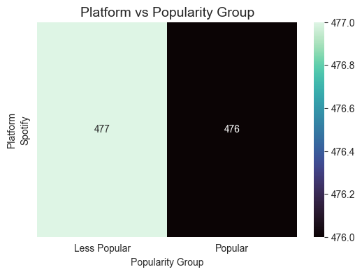

```python
median_streams = df['streams'].median()
df['popularity_group'] = ['Popular' if s > median_streams else 'Less Popular' for s in df['streams']]

df['Platform'] = df.apply(
    lambda row: 'Spotify' if row['in_spotify_playlists'] > row['in_apple_playlists'] else 'Apple Music',
    axis=1
)

contingency_table = pd.crosstab(df['Platform'], df['popularity_group'])
print("Contingency Table:\n")
print(contingency_table)

plt.figure(figsize=(6,4))
sns.heatmap(contingency_table, annot=True, cmap="mako", fmt="d")
plt.title("Platform vs Popularity Group", fontsize=14)
plt.xlabel("Popularity Group")
plt.ylabel("Platform")
plt.grid(True, axis='y', linestyle='--', alpha=0.7)
plt.show()
```

```python
chi2_stat, p_value, dof, expected = chi2_contingency(contingency_table)

print(f"Chi-Squared Statistic: {chi2_stat:.4f}")
print(f"Degrees of Freedom: {dof}")
print(f"P-Value: {p_value:.4f}")

if p_value < 0.05:
    print("\nResult: P-value < 0.05 → Reject the null hypothesis.")
    print("Conclusion: There is a significant relationship between platform and popularity.")
else:
    print("\nResult: P-value ≥ 0.05 → Fail to reject the null hypothesis.")
    print("Conclusion: There is no significant relationship between platform and popularity.")
```

```
Chi-Squared Statistic: 0.0000
Degrees of Freedom: 0
P-Value: 1.0000

Result: P-value ≥ 0.05 → Fail to reject the null hypothesis.
Conclusion: There is no significant relationship between platform and popularity.
```

Third Method: Relationship between Continuous Variables (Pearson's Correlation Test)

first you'll want to import pearsonr from the scipy.stats library. Scipy is a Python library with lots of useful code already written for others to use. We're taking from the "stats" sub library which contains lots of functions that make running statistical tests on data very simple. Pearsonr will let us run Pearson's Correlation Test on our data with ease. For further reading see: https://docs.scipy.org/doc/scipy/reference/stats.html

```python
from scipy.stats import pearsonr
```

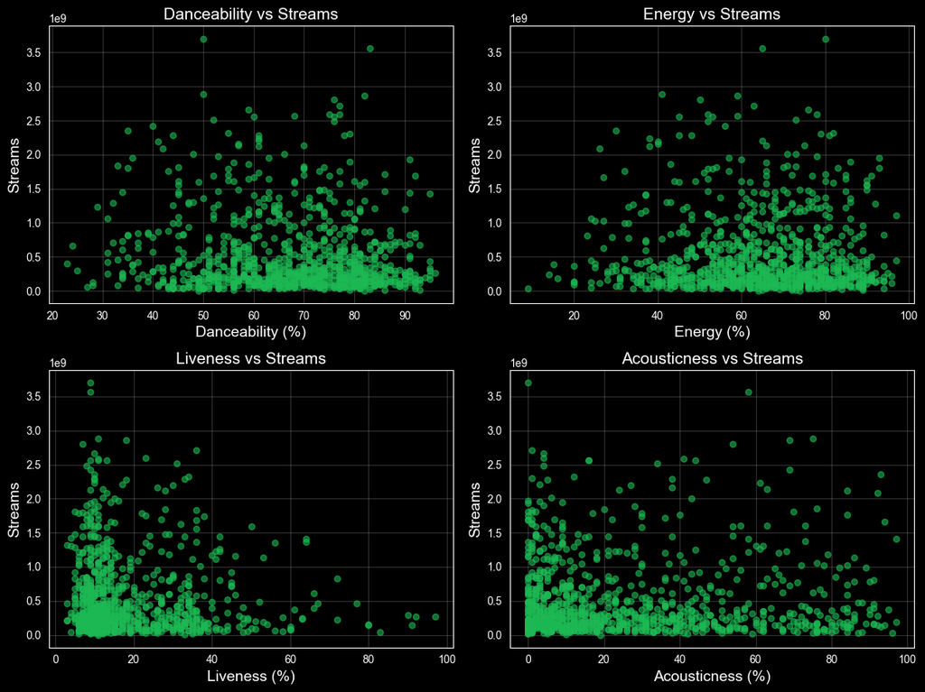

```python
metrics = ['danceability_%', 'energy_%', 'liveness_%', 'acousticness_%']

plt.style.use('dark_background')
# Create scatter plots
plt.figure(figsize=(12, 9))

for i, metric in enumerate(metrics, 1):
    plt.subplot(2, 2, i)  # 2 rows, 2 columns
    plt.scatter(df[metric], df['streams'], alpha=0.6, s=30, color='#1DB954')
    plt.xlabel(metric.replace('_%', ' (%)').capitalize(), fontsize=14)
    plt.ylabel("Streams", fontsize=14)
    plt.title(f"{metric.replace('_%', '').capitalize()} vs Streams", fontsize=15)
    plt.grid(alpha=0.2)

plt.tight_layout()
plt.show()
```

Looking at these scatter plots, there does not seem to be any obvious hints of correlation. Now for the Pearson Correlation Tests. Those will give some actual numbers to examine. Once again we define a an array with each metric we're interested in to loop through and test. "r" is being set to the Pearson correlation coefficient and "p_value" is the p-value returned by the test.

```python
metrics = ['danceability_%', 'energy_%', 'liveness_%', 'acousticness_%']

for metric in metrics:
    r, p_value = pearsonr(df[metric], df['streams'])
    print(f"{metric.capitalize()} vs Streams:")
    print(f"  Pearson correlation (r): {r:.3f}")
    print(f"  P-value: {p_value:.5f}")
    print()
```

```
Danceability_% vs Streams:
  Pearson correlation (r): -0.105
  P-value: 0.00117

Energy_% vs Streams:
  Pearson correlation (r): -0.026
  P-value: 0.41975

Liveness_% vs Streams:
  Pearson correlation (r): -0.048
  P-value: 0.13626

Acousticness_% vs Streams:
  Pearson correlation (r): -0.004
  P-value: 0.89787
```

It seems none of these musical metrics show a strong linear relationship with stream counts seeing as all four correlation tests returned values very close to 0. The greatest relationship was "danceability" vs "streams" with r = -0.105 which is so small you can't make any practical inferences from this. Moreover, this is the only statistically significant relationship with p < 0.05.

# Primary Analysis

Based on the previous exploratory data analysis- especially the last one, correlating danceability, energy, liveness, and accousticness- there unfortunately seems to be little correlation between what a song "sounds" like and how popular it is, based on number of streams.  
In the next section, we'll train learning models on predicting the number of streams a song has based on how many playlists it is in.

=============================================================

First we import some useful packages to prepare our data and train the model. Then we separate our data into what can be used to make predictions, and the value we want to predict. So Y is set equal to data in the "streams" column, and X is set equal to other columns related to the presense of the song in a playlist.

See the following for more details on the packages: https://scikit-learn.org/stable/modules/linear_model.html https://scikit-learn.org/stable/api/sklearn.model_selection.html https://scikit-learn.org/stable/modules/preprocessing.html

```python
from sklearn.linear_model import LinearRegression
from sklearn.model_selection import train_test_split
from sklearn.preprocessing import StandardScaler

X = df[["in_spotify_playlists", "in_spotify_charts", "in_apple_charts", "in_apple_playlists", "in_deezer_charts", "in_shazam_charts"]]
y = df["streams"]
```

Next we create a scaler to normalize our feature values which is very important when their magnitudes differ.

```python
scaler = StandardScaler()
```

Now we split our data into two sets, a "training" set, which will be 80% of our data and a "test" set, which is the remaining 20%. The training set will be used to actually train the model, and the test set will be used to test the final model's performance.

```python
X_train, X_test, y_train, y_test = train_test_split(X, y, test_size=0.2, random_state=42)
X_train = scaler.fit_transform(X_train)
X_test = scaler.transform(X_test)
```

With the data split, we create a LinearRegression model and use the "fit" function with the X_train and corresponding y_train datasets so the model can learn the relationship between the two.

```python
model = LinearRegression()

model.fit(X_train, y_train);
```

Now that our model is fitted, we want to know how well it performs. So, we use model.score with the test data we split earlier to obtain an r^2 value indicating how well our model's predictions match the actual value.

```python
y_pred = model.predict(X_test)

print(model.score(X_test, y_test))
```

```
0.699053258321356
```

It looks like the r^2 value was 0.699 which means our model can explain about 70% of the variation in the number of streams of a song given data on how many playlists it is in. 0.699 is pretty solid, so we can say our model does a decent job at predicting number of streams.

=============================================================

```python
from sklearn.linear_model import Lasso

X_train, X_test, y_train, y_test = train_test_split(X, y, test_size=0.2, random_state=42)

model2 = Lasso()

model2.fit(X_train, y_train)

y_pred = model2.predict(X_test)

print(model2.score(X_test, y_test))
```

```
0.6990532583343854
```

Looks like the results were incredibly similar to the previous model. Not much to see here.

=============================================================

```python
from sklearn.ensemble import RandomForestRegressor
from sklearn.metrics import r2_score, mean_squared_error

model3 = RandomForestRegressor(n_estimators=100, random_state=42)

model3.fit(X_train, y_train)

y_pred = model3.predict(X_test)

print(r2_score(y_test, y_pred))
```

```
0.6976811927395723
```

Wow 0.697, our results are not varying by much. This model seems to have performed ever so slightly worse than the prior two models. Let's try one more model.

=============================================================

Our last model is a Gradient Boosting Regressor Model. Similar to the previous model it uses trees, but instead of building a bunch of models independently all at once and averaging their results, this model builds each tree sequentially using each successive tree to try and fix the mistakes of the previous tree. See https://scikit-learn.org/stable/modules/generated/sklearn.ensemble.GradientBoostingRegressor.html for more details

```python
from sklearn.ensemble import GradientBoostingRegressor

model4 = GradientBoostingRegressor(n_estimators=200, learning_rate=0.1, max_depth=3, random_state=42)

model4.fit(X_train, y_train)
y_pred = model4.predict(X_test)

print(r2_score(y_test, y_pred))
```

```
0.7095595646626762
```

All right! The last model we tried seems to have just barely beat out the other three an r^2 score of 0.709.

# Visualization

After training four different models (Linear Regression, Lasso, Random Forest, and Gradient Boosting), we visualized their performance to determine the best approach for predicting song streams. We also analyzed the feature importance to understand which factors drive a song's popularity the most.

Model Comparison:

First, we compared the R^2 scores of all four models. The R^2 score represents the proportion of the variance for the dependent variable (Streams) that's explained by our independent variables (Playlists/Charts).

As shown in the chart below, the Gradient Boosting Regressor performed the best with an R^2 of approximately 0.71. However, it is worth noting that the simple Linear Regression model performed nearly as well (~0.70), suggesting that the relationship between playlist count and total streams is largely linear.

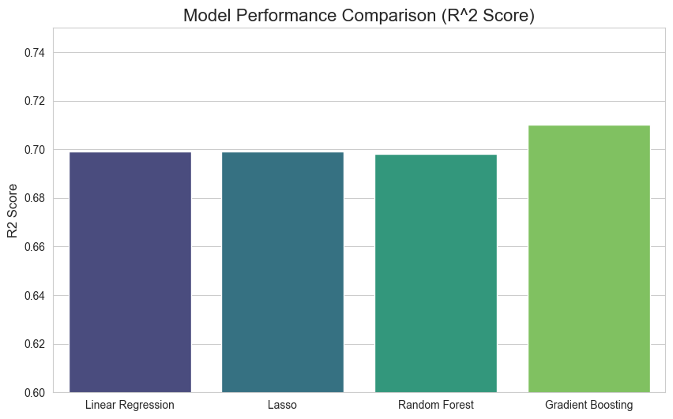

```python
models = ['Linear Regression', 'Lasso', 'Random Forest', 'Gradient Boosting']
scores = [0.699, 0.699, 0.698, 0.710] # Values from analysis

# Set the visual style
sns.set_style("whitegrid")

# 1. Model Comparison Plot
plt.figure(figsize=(10, 6))
sns.barplot(x=models, y=scores, palette='viridis')
plt.title('Model Performance Comparison (R^2 Score)', fontsize=16)
plt.ylabel('R2 Score', fontsize=12)
plt.ylim(0.6, 0.75)
plt.show()
```

Accuracy of the Best Model:

To visualize the accuracy of our best model (Gradient Boosting), we plotted the Predicted Streams against the Actual Streams from our test set.

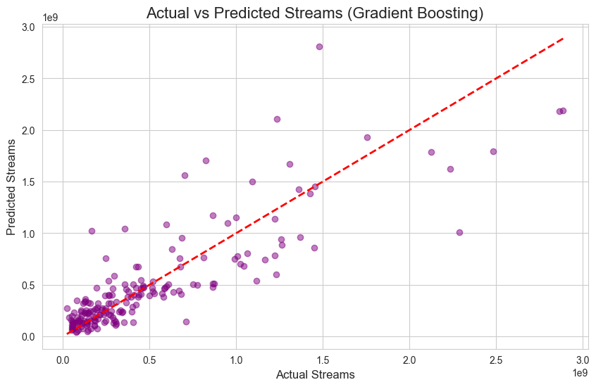

```python
# 2. Actual vs Predicted (Best Model: Gradient Boosting)
plt.figure(figsize=(10, 6))
plt.scatter(y_test, y_pred, alpha=0.5, color='purple')
plt.plot([y_test.min(), y_test.max()], [y_test.min(), y_test.max()], 'r--', lw=2)
plt.xlabel('Actual Streams', fontsize=12)
plt.ylabel('Predicted Streams', fontsize=12)
plt.title('Actual vs Predicted Streams (Gradient Boosting)', fontsize=16)
plt.show()
```

Feature Importance:

Finally, we extracted the feature importance scores from the Gradient Boosting model to answer our primary research question: What makes a song popular?

The results were decisive. in_spotify_playlists is by far the most significant predictor of total streams, accounting for nearly 79% of the model's decision-making power. Interestingly, being in Apple Music playlists or charts had a much smaller impact on total streams compared to Spotify's curated playlists. This suggests that for an artist, getting added to Spotify editorial playlists is the single most effective driver of commercial success.

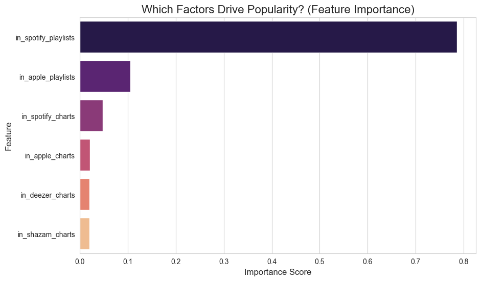

```python
feature_importance = model4.feature_importances_
features = X.columns
indices = np.argsort(feature_importance)[::-1]

plt.figure(figsize=(10, 6))
sns.barplot(x=feature_importance[indices], y=features[indices], palette='magma')
plt.title('Which Factors Drive Popularity? (Feature Importance)', fontsize=16)
plt.xlabel('Importance Score', fontsize=12)
plt.ylabel('Feature', fontsize=12)
plt.show()
```

Residual Plot

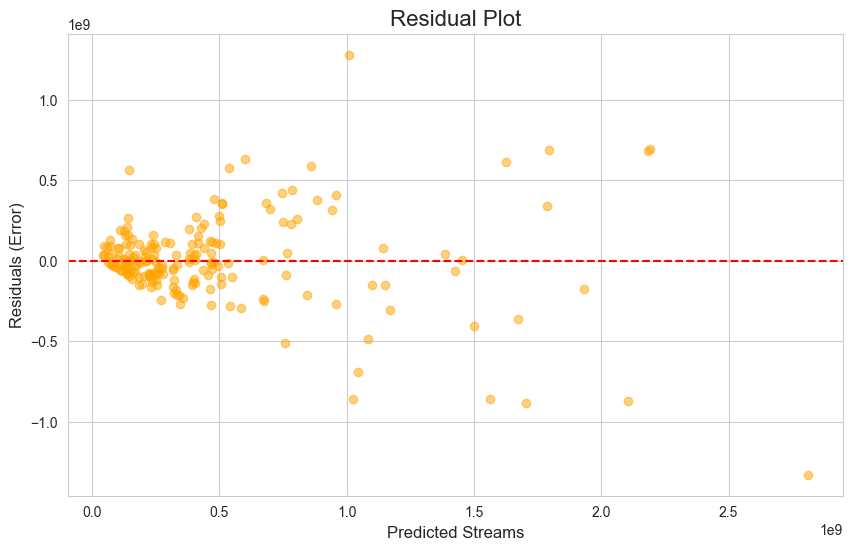

```python
residuals = y_test - y_pred
plt.figure(figsize=(10, 6))
plt.scatter(y_pred, residuals, alpha=0.5, color='orange')
plt.axhline(y=0, color='r', linestyle='--')
plt.xlabel('Predicted Streams', fontsize=12)
plt.ylabel('Residuals (Error)', fontsize=12)
plt.title('Residual Plot', fontsize=16)
plt.show()
```

# Insights and Conclusions

Overall, our results show that popularity is influenced far more by exposure than by musical characteristics. Playlist placement, chart presence, and overall visibility play a much larger role in driving streams than features like danceability or energy. Future work could include artist popularity, social media trends, or release timing to better understand other factors that contribute to a song becoming successful.